# Section 1.2 Measuring the Strength of Evidence

Last updated Saturday, August 23, 2025 @ 12:29 AM

## Before We Begin…

These slides were created to accompany the text [*Introduction to Statistical Investigations, 2nd Edition*](http://www.isi-stats.com/isi/index2nd.html) — Section 1.2 Measuring the Strength of Evidence.

*This content does not replace reading the relevant textbook section.* It is for class presentation, review, and reference.

See [AsULearn](https://asulearn.appstate.edu/) for additional readings, videos, and assignments.

You can print these slides to a pdf for offline use using the print function in your browser.

## The Spiral Approach & The Four Pillars

- **We will address strength of evidence (*significance*) in Chapter 1.**
- We will discuss breadth of results (*generalization*) in Chapter 2.
- We will learn about effect size of results (*estimation*) in Chapter 3.
- Chapter 4 will introduce the concept of *causation*, the last of the four pillars.

## Learning Goals for Chapter 1

- Use the chance model to determine whether an observed statistic is unlikely to occur. [Section 1.1]
- Calculate and interpret a *p*-value, and state the strength of evidence it provides against a null hypothesis. [Section 1.2]
- Calculate a standardized statistic for a single proportion and evaluate the strength of evidence it provides against a null hypothesis. [Section 1.3]
- Describe how the distance of the observed statistic from the parameter value specified by the null hypothesis, sample size, and one- vs. two-sided tests affect the strength of evidence against the null hypothesis. [Section 1.4]

We will *not* cover Section 1.5, which introduces a theory-based method of inference for a single proportion.

## Learning Goals for Section 1.2

- Use appropriate symbols for parameter and statistic.
- State the null and the alternative hypotheses in words and in terms of the symbol \(\pi\), the long-run proportion.
- Explain how to conduct a simulation using a null hypothesis probability that is not 50-50.
- Use the ISI [One Proportion](http://www.isi-stats.com/isi2nd/ISIapplets2021.html) applet to obtain the *p*-value after carrying out an appropriate simulation.
- Anticipate the null distribution’s center and how it changes based on using proportion or count as the statistic.
- Interpret the *p*-value and explain why a smaller *p*-value provides stronger evidence against the null hypothesis.
- State a conclusion about the alternative hypothesis and null hypothesis based on the *p*-value.

## Section 1.2 New Vocabulary

**binary variable :** a categorical variable with only two outcomes

- we can regroup multiple outcomes into **two** categories
- one of the categories would be defined as a “success”
- the other category would be defined as a “failure”

*Example 1:* The outcome of one coin flip (heads vs. tails) is a very common binary variable. In a pre-game coin flip in football, one team designates what will be a “success” by calling heads or tails before the flip occurs.

*Example 2:* The six possible numbers that result from one roll of a six-sided die can be regrouped into odd vs. even numbers. We could then designate even numbers as the “success”.

An essential part of our statistical *logic of inference* is creating a pair of opposing hypotheses that make statements regarding a parameter of the random process we are investigating.

Recall from our Section 1.1 vocabulary: *a **parameter** is a long-run numerical property of some real-world random process.*

**null hypothesis (\(H_0\)) :** “by chance alone” or “there is no effect” explanation, which can be modeled by random simulation

**null distribution :** a distribution of simulated statistics that are a representation of what *could have* happened in the actual study if \(H_0\) were true (we *assume* \(H_0\) is true in the simulation)

**alternative hypothesis (\(H_a\)) :** “not by chance alone” or “there is an effect” explanation, typically reflects our research conjecture (it is also sometimes referred to as the *research hypothesis*)

## Statistical Symbols

We often use symbols to communicate or represent different quantities in a statistical analysis or to express our hypotheses.

It is common to use Greek letters to represent parameters and Roman letters (our regular English alphabet) for statistics.

\(\pi\) : The Greek letter pi (or *p*), pronounced “pie.” This represents a parameter that is a proportion or probability (*not* 3.14159).

\(\hat{p}\) : The Roman letter p with a ^ above it, pronounced as “p-hat.” It is the proportion of observational units in a sample that have a particular characteristic (or an *estimated probability*). For a *test of significance*, this would be the observed statistic.

\(n\) : sample size; the number of observational units in the sample

## Test of Significance

In the field of Statistics, a **test of significance** is a procedure for measuring the strength of evidence against our null hypothesis.

1. Make a claim about the parameter of interest (\(H_0\) and \(H_a\))
2. Gather and explore data
3. Follow the **3S** strategy to
   - calculate an observed *Statistic* from the gathered data
   - *Simulate* a null distribution (*scenario assuming \(H_0\) is true*)
   - compare the *statistic* to the *simulated* null distribution to measure the *Strength of evidence* it provides *against* \(H_0\).
4. Draw a conclusion about the plausibility \(H_0\) and whether the test result is statistically significant—leading us to reject \(H_0\).

## Quantifying *Strength of Evidence*

Assuming \(H_0\) is true … our *p*-value is the probability of getting a purely random value of the statistic that is at least as extreme as the observed statistic we are assessing.

| Magnitude of the *p*-value | Strength of evidence provided by the *p*-value |
| --- | --- |
| *p*-value > 0.10 | **NOT MUCH** evidence against the null hypothesis (\(H_0\)) |
| 0.05 < *p*-value ≤ 0.10 | **MODERATE** evidence against the null hypothesis (\(H_0\)) |
| 0.01 < *p*-value ≤ 0.05 | **STRONG** evidence against the null hypothesis (\(H_0\)) |
| *p*-value ≤ 0.01 | **VERY STRONG** evidence against the null hypothesis (\(H_0\)) |

## Additional Guidelines (*p*-value ≤ 0.05)

Researchers across many of disciplines consider *p*-value ≤ 0.05 to be the threshold where we can: (1) claim that our test results have *statistical significance*; (2) declare the chance model to be implausible; and thus (3) reject \(H_0\) and accept \(H_a\) instead.

A *p*-value ≤ 0.05 indicates we have *strong* or *very strong evidence* against the null hypothesis, as per our textbook guidelines.

In some situations you may want or need stronger evidence. For example, rejecting \(H_0\) may have life or death consequences in a medical study, so the researchers might use *p*-value ≤ 0.01 (only *very strong evidence*) as their chosen level of significance.

You may be wondering, why this particular probability (≤ 0.05)? What’s so special about it?

## So Why 0.05?

Ronald Fisher wrote *Statistical Methods for Research Workers* in 1925. He chose 1 in 20 (5%) as his general cutoff value, because it typically corresponds to about two standard deviations from the expected value. (*Though there is some [disagreement](https://www.scientificamerican.com/article/the-significant-problem-of-p-values/)…*)

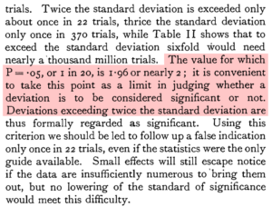

## The ISI [One Proportion](http://www.isi-stats.com/isi2nd/ISIapplets2021.html) Applet

- Probability of heads = value of \(\pi\) in \(H_0\)
- Number of tosses = \(n\) (sample size)
- Number of repetitions = 1000 (or more simulations)
- *Statistic* goes in the Count Samples box

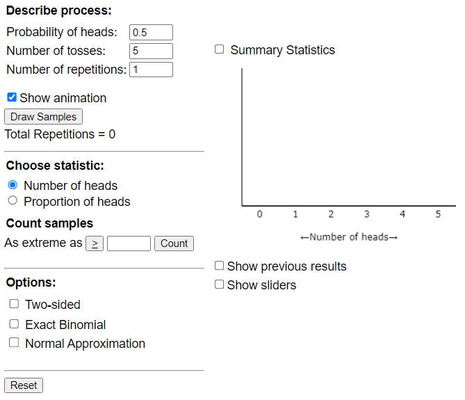

If you enter a “Probability of heads” other than 0.5, the labels change to more general terms. Notice the statistical symbols.

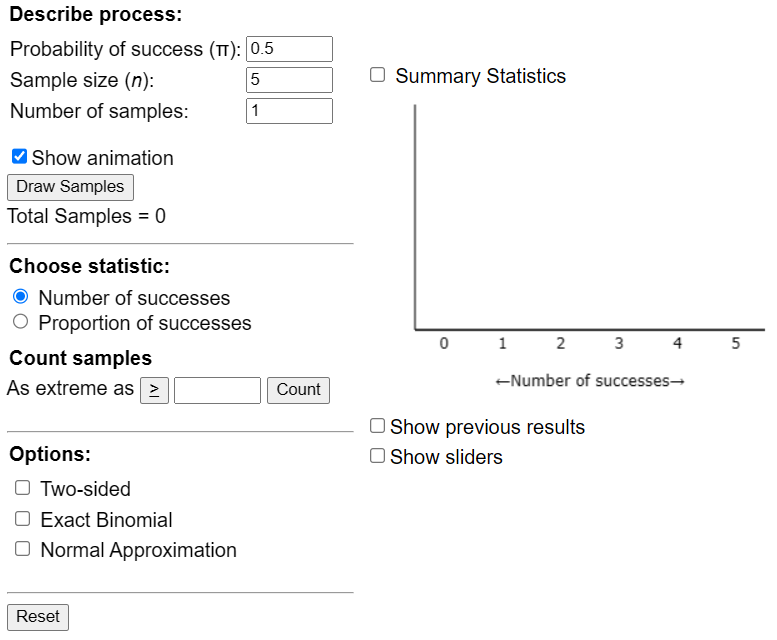

## General Rule for Statistical Significance

We will declare the chance model *implausible* and reject \(H_0\) if…

[figure not shown]

With all due respect to the [late, great Freddie Mercury](https://youtu.be/FP808MiJUcM).